# Practical Machine Learning Course Project

George Kolev

May 22, 2016

## Background

Using devices such as *Jawbone Up*, *Nike FuelBand*, and *Fitbit* it is now possible to collect a large amount of data about personal activity relatively inexpensively. One thing that people regularly do is quantify how much of a particular activity they do, but they rarely quantify *how well* they do it.

In this project, we use data from accelerometers on the belt, forearm, arm, and dumbell of 6 participants, who were asked to perform barbell lifts. More information is available at http://groupware.les.inf.puc-rio.br/har.

The goal is to predict the manner in which the participants performed an exercise, or the `classe` variable in the dataset, using any of the other variables. There are five different classes:

- Class A - exactly according to the instructions;
- Class B - throwing the elbows to the front;
- Class C - lifting the dumbbell only halfway;
- Class D - lowering the dumbbell only halfway; and
- Class E - throwing the hips to the front.

Scripts were written and tested on RSudio Version 0.99.473 running on OS X El Capitan Version 10.11.4 (15E65).

## Data Preprocessing

### Setup and data import

We load the data, which have been split into `test` and `train` sets, containing, respectivelly, 20 and 19,622 observations of 160 variables.

```r
## Load required R packages
library(lattice)
library(ggplot2)
library(caret)
library(randomForest)
library(rpart)
library(rpart.plot)
library(corrplot)
library(rattle)

## Set the seed for reproduceability
set.seed(12345)

## Load data from the provided URLs and instruct R to read "NA", "#DIV/0!", and blank strings as NA values.
trainurl <- "https://d396qusza40orc.cloudfront.net/predmachlearn/pml-training.csv"
testurl <- "https://d396qusza40orc.cloudfront.net/predmachlearn/pml-testing.csv"
train <- read.csv(url(trainurl), na.strings = c("NA", "#DIV/0!", ""), header = TRUE)
test <- read.csv(url(testurl), na.strings = c("NA", "#DIV/0!", ""), header = TRUE)
```

### Data slicing

We partition the `train` data set into two sets using a 75% split, in order to perform cross-validation and evaluate our prediction models.

```r
inTrain <- createDataPartition(y = train$classe, p = 0.75, list = FALSE)
subTrain <- train[inTrain, ]
subTest <- train[-inTrain, ]
```

### Data cleaning

We remove columns with missing values.

```r
subTrain <-subTrain[,colSums(is.na(train)) == 0]
```

We also remove the first seven variables, which appear irrelevant to this analysis.

```r
subTrain <-subTrain[, -c(1:7)]
```

We are left with 53 variables: `classe` and 52 potential predictors.

### Other preprocessing

We check for predictors with near-zero variance.

```r
nzv <- nearZeroVar(subTrain, saveMetrics=TRUE)
nrow(nzv[nzv$nzv == TRUE, ])
```

```
## [1] 0
```

We check for highly correlated predictors (corr > 0.8). There are several instances of high correlation, indicated by the dark blue circles in the multicollinearity plot in the Graphs section. We remove these variables.

```r
M <- abs(cor(subTrain[, - 53]))
high_corr <- findCorrelation(M, cutoff = 0.8)
subTrain <- subTrain[, -high_corr]
```

We are left with 40 variables.

## Methodology

We will use classification trees and the random forrest method, and compare the accuracy of each model. We perform 5-fold cross validation.

```r
control <- trainControl(method = "cv", number = 5)
```

## Prediction Algorithms

```r
## Create models
mod_rpart <- train(classe ~., data = subTrain, method = "rpart", trControl = control)
mod_rf <- train(classe ~., data = subTrain, method = "rf", trControl = control)

## Predict
pred_rpart <- predict(mod_rpart, subTest)
pred_rf <- predict(mod_rf, subTest)

## Accuracy
confusionMatrix(pred_rpart, subTest$classe)$overall[1]
```

```
##  Accuracy
## 0.5358891
```

```r
confusionMatrix(pred_rf, subTest$classe)$overall[1]
```

```
##  Accuracy
## 0.9926591
```

The classification tree model has an accuracy of 53.59%. The random forest model has a much better accuracy of 99.27%, and its expected out-of-sample error rate is 0.73%.

## Prediction

We apply the random forest algorithm to the original test set of 20 observations.

```r
predict(mod_rf, test)
```

```
##  [1] B A B A A E D B A A B C B A E E A B B B
## Levels: A B C D E
```

## References

Velloso, E., Bulling, A., Gellersen, H., Ugulino, W., and Fuks, H. for *Qualitative Activity Recognition of Weight Lifting Exercises.* Proceedings of 4th International Conference in Cooperation with SIGCHI (Augmented Human ’13) . Stuttgart, Germany: ACM SIGCHI, 2013.

## Graphs

#### Multicollinearity Plot

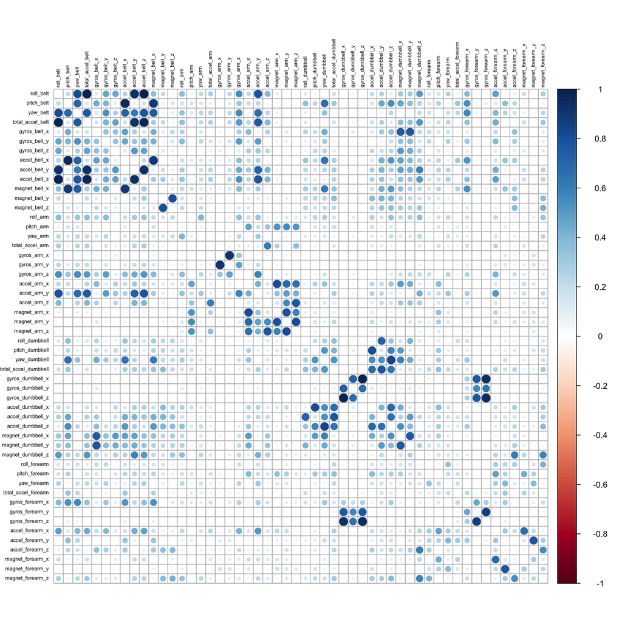

```r
diag(M) <- 0 ## Remove diagonal values of correlation matrix (i.e. correlation of variables with themselves).
corrplot(M, tl.cex = 0.5, tl.col = "black", method = "circle") ## Generate correlation plot.
```

#### Classification Tree Model

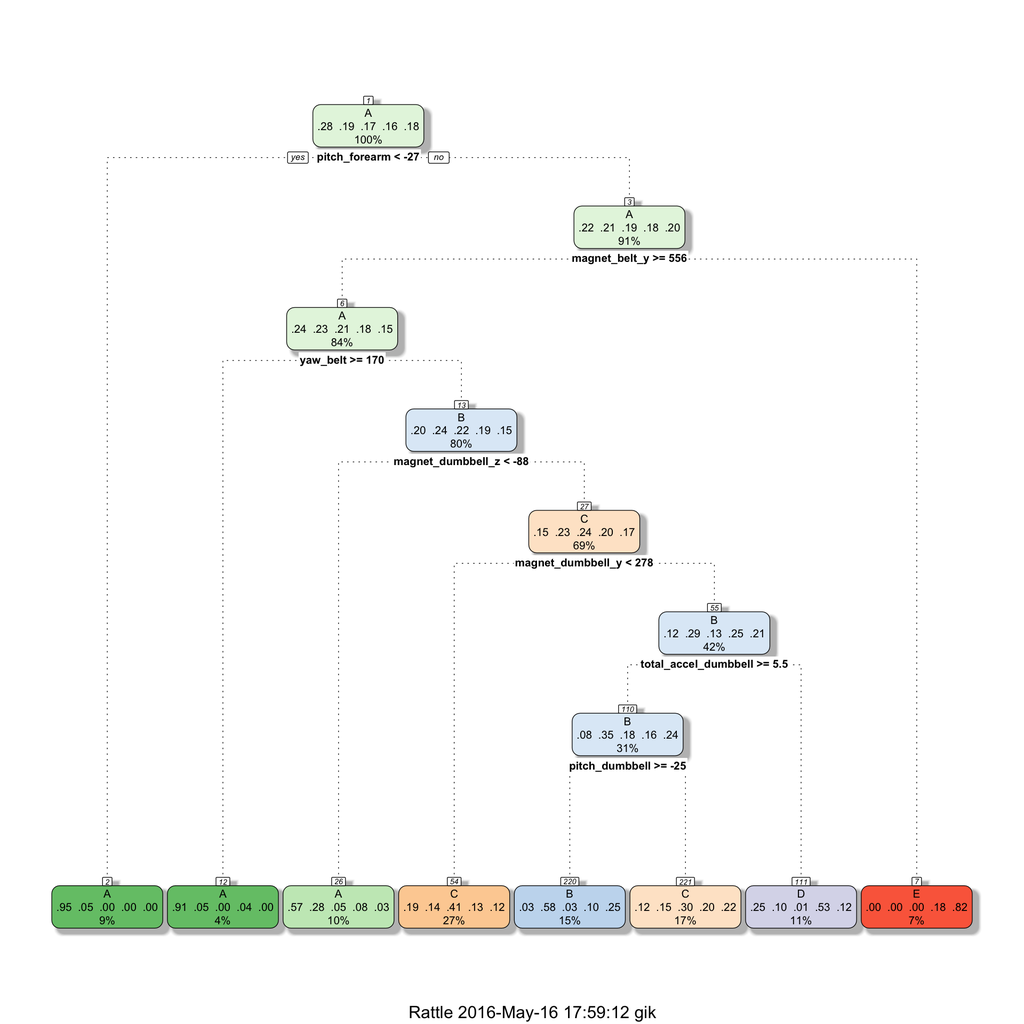

```r
fancyRpartPlot(mod_rpart$finalModel)
```